# Tutorial 7: Shrinkage

March 4, 2018

In this example, we look at several aspects of the voting records of the US Congress of 2017. The votes were compiled from http://clerk.house.gov.

Data preprocessing is written in Python. We generated the data file `2017_cleaned_votes.csv`.

```r
setwd("C:/Users/cheny/Desktop/study/second term/staistical machine learning/tutorial/tutorial seven")
votes = read.table("2017_cleaned_votes.csv", header = TRUE, sep = ";")
full_votes = read.table("2017_votes.csv", header = TRUE, sep = ";")
dim(votes)
```

```
[1] 424 710
```

```r
summary(votes$party)
```

```
  D   R
191 233
```

First, we perform the principal components analysis. As implemented in `R`, PCA only works when there are fewer votes, than members. Letâs take a random sample of 100 votes and look at the result.

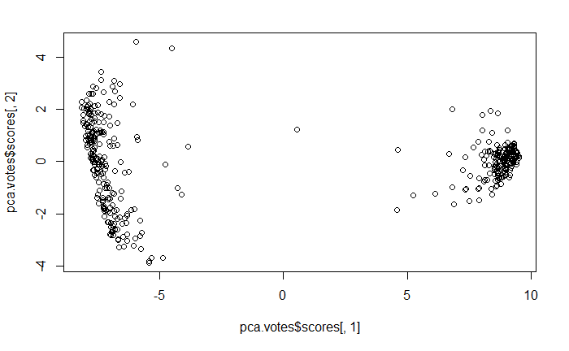

```r
set.seed(0)  # this can be changed
subset = sample(2:ncol(votes), 100)
pca.votes = princomp(votes[, subset])
plot(pca.votes$scores[, 1], pca.votes$scores[, 2])
```

This data is also âsupervisedâ, in the sense that we have a label: the memberâs party. Letâs color our points with this label.

```r
red = votes$party == "R"
blue = votes$party == "D"
plot(pca.votes$scores[, 1], pca.votes$scores[, 2], type = "n", xlab = "Variable 1", ylab = "Variable 2")
points(pca.votes$scores[red, 1], pca.votes$scores[red, 2], pch = 23, bg = "red")
```

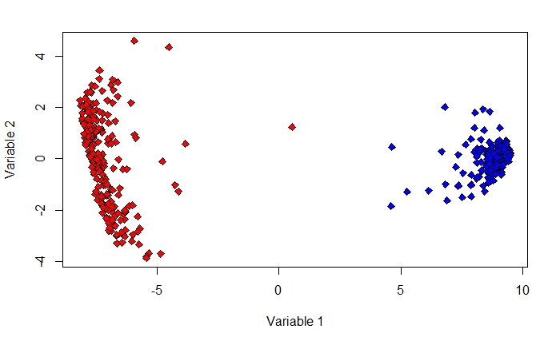

```r
points(pca.votes$scores[blue, 1], pca.votes$scores[blue, 2], pch = 23, bg = "blue")
```

The plot verifies the fact that the votes are clusteredy by parties. In fact, there is some separation between the two parties along Variable 1. However, there does not appear to be much separation between the parties on Variable 2.

We first fit a logistic regression model to our data. The model assumption is $n \geq p$, so we will only use the randomly selected 100 votes.

```r
votes.selected = as.data.frame(cbind(votes$party, votes[, subset]))
colnames(votes.selected) = colnames(votes)[c(1, subset)]

logistic.fit = glm(party ~ ., data= votes.selected, family = binomial())
summary(logistic.fit)
```

[output not shown]

In this case, since the two classes are well separated, so the model suffers from the high variance, which is reflected by the variance of coefficients.

How well did the model fit? Well, the logistic model estimates probabilities between 0 or 1. We can turn these into 0-1 labels by the rule: assign 1 if the probability is > 0.5, 0 otherwise.

```r
party_N = numeric(length(votes$party))
party_N[red] = 1
party_N[blue] = 0

glm.probs = predict(logistic.fit, type="response")
predictions_logistic = glm.probs > 0.5
sum(predictions_logistic != party_N)
```

[output not shown]

The model can still be used for making predictions, and the training error is zero! To be fair, we want to use part of the data to fit the model and then make predictions on the rest. Letâs take a subset of 150 members, and then see how well our classifier does.

```r
set.seed(5)
train = sample(1:nrow(votes), 150)
glm.fit = glm(party ~ ., data = votes.selected, family = binomial(), subset=train)
summary(glm.fit)
```

[output not shown]

We will summarize the prediction result by a confusion matrix.

```r
glm.probs = predict(glm.fit, votes.selected[-train,], type="response")
glm.pred = glm.probs > 0.5
sum(glm.pred != party_N[-train])
table(party_N[-train], glm.pred)
```

[output not shown]

Next, we will fit the model with $L_1$ penalty. In our case, $n < p$. The penalized model has the form
$$\min_{\beta} -\mbox{loglik}/n + \lambda \sum_{j=1}^p |\beta_j|.$$
We select optimal value of $\lambda$ by crossvalidation. We will use the `R` package `glmnet` to fit the model.

```r
library(glmnet)
lasso.fit<-glmnet(as.matrix(votes[train, -1]), party_N[train], family = "binomial")
lasso.cv<-cv.glmnet(as.matrix(votes[train, -1]), party_N[train],family = "binomial", type.measure = "class")
plot(lasso.fit)
lasso.coef <- predict(lasso.fit, type = "coefficients", s = lasso.cv$lambda.1se )
lasso.coef
```

[output not shown]

From this model fit, we known that bill 4 are very partisan, achieving perfect separation. Here is the [bill](http://clerk.house.gov/evs/2017/roll004.xml). We see that all 193 Democrats voted N, 237 Republicans voted Y, and 3 Republican did not vote. If we use the $L_1$ penalized model, it can perform variable selection automatically. Only the coefficient of bill 4 is nonzero!

Let’s check the prediction by the new model with an optimal $\lambda$.

```r
lasso.prob = predict(lasso.fit, s= lasso.cv$lambda.1se, newx = as.matrix(votes[-train, -1]),type = "response")
lasso.pred = lasso.prob>0.5
table(party_N[-train], lasso.pred)
```

[output not shown]

The accuracy has been improved!

Now, let’s consider the $L_2$ penalized model
$$\min_{\beta} -\mbox{loglik}/n + \lambda \sum_{j=1}^p \beta_j^2.$$

```r
ridge.fit<-glmnet(as.matrix(votes[train, -1]), party_N[train],alpha = 0, family = "binomial")
plot(ridge.fit)
ridge.cv<-cv.glmnet(as.matrix(votes[train, -1]), party_N[train],alpha=0, family = "binomial", type.measure = "deviance")
ridge.coef <- predict(ridge.fit, type = "coefficients", s = ridge.cv$lambda.1se )
ridge.coef
```

[output not shown]

If we use the $L_2$ penalty, we get a lot of small nonzero coefficients. We are able to apply the ridge regression to the case when $n< p$, but it can not contribute to the variable selection. Let’s check the model prediction.

```r
ridge.prob = predict(ridge.fit, s= ridge.cv$lambda.1se, newx = as.matrix(votes[-train, -1]),type = "response")
ridge.pred = ridge.prob>0.5
table(party_N[-train], ridge.pred)
```

[output not shown]

The accuracy has also been improved compared to that of logistic regression.